# 2021-12-15_posterdown

## 引言

posterdown自动排版，通过调节参数满足个人制作海报的需要。

## 1. 介绍

目前posterdown支持3种风格的海报模板：posterdown_html、posterdown_betterland和posterdown_betterport。以posterdown_betterport为例进行阐述。

[figure not shown]

目前支持的三种模板风格

## 2. 创建海报

### 2.1 创建模板

直接通过新建R Markdown文件，选择posterdown模板则自动导入模板代码，如下：

[figure not shown]

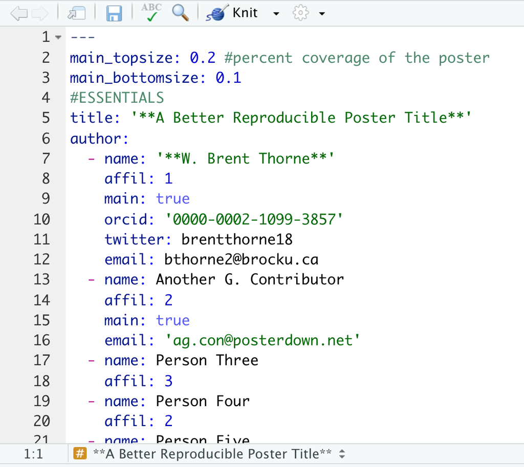

创建模板

### 2.2 添加内容

按照R Markdown语法进行代码块、图片、文字等等的添加，通过点击knit进行渲染，查看在模板基础上更改的内容。点击knit后自动生成包含html在内的如下文件：

```powershell
.
├── A\ Better\ Reproducible\ Poster\ Title.pdf
├── packages.bib
├── poster.Rmd
├── poster.html
└── poster_files
    ├── figure-html
    │   ├── irisfigure-1.png
    │   └── myprettycode-1.png
    ├── header-attrs-2.11
    │   └── header-attrs.js
    └── paged-0.15

4 directories, 7 files
```

- 图片

可以在该目录下再建立一个Figures文件夹存放Rmd中使用到的图片。

- html文件

默认生成的html文件名前缀和Rmd文件一致，可以通过在Rmd文档**开头**添加代码自定义生成的html文件名，这里为index.html：

```r
knit: (function(inputFile, encoding) { rmarkdown::render(inputFile, encoding = encoding, output_file = file.path(dirname(inputFile), 'index.html')) })
```

- 海报大小设置

通过横宽两个参数设定，支持cm，in，mm这几个长度单位，在文档**开头**加入代码：

```r
poster_height: "90cm"
poster_width: "60cm"
```

- 字体大小

在文档开头加入代码：

```r
main_textsize: "70pt"
body_textsize: "30px"
```

更多参数设置可以参考GitHub上发布的[官方指南](https://github.com/brentthorne/posterdown/wiki/posterdown_betterland)，另外还有一份更详细的[补充参数指南](https://pythonawesome.com/use-rmarkdown-to-generate-pdf-conference-posters-via-html-or-latex/)，可具体到该参数支持的长度单位也包含哪些。

### 2.3 导出html以及pdf

有多种方法，可以归纳为两种，一种是将Rmd直接转换为PDF，一种是渲染的html文件转换为PDF，能够满足转换的工具都可以尝试使用，不局限于使用R或者其他的方法实现。

- 根据Github上的issue作者的提议，可以使用`pagedown`包中的函数:`pagedown::chrome_print("myfile.Rmd")`，直接将Rmd导出为PDF，但是该函数并未使用成功，有待后续解决。
- 使用render将Rmd导出为PDF

```r
render("input.Rmd", "pdf_document")
```

该函数导出的PDF并未进行很好的渲染。

- 尝试了使用pandoc对html转换为PDF，但是渲染效果不好。
- 使用Safari浏览器直接将knit的html文件导出为PDF，能够渲染的很好。

[figure not shown]

## 参考资料：

- [具体的参数调整官方文档](https://github.com/brentthorne/posterdown/wiki/posterdown_betterland)